# 12 — Archetype Trade-offs

PGA Tour Distance & Speed Analytics

2026-07-08

# Overview

**Question:** Project 10’s Section 4 found “Long/Accurate” is the archetype gaining ground among top performers, and both short-hitting archetypes are declining as a share of the elite. Two outlier groups within that story deserve a closer look:

1. **Short/Inaccurate golfers who still post Top-25 seasons.** The quadrant heuristic says this archetype shouldn’t win — where do these outliers actually gain their strokes, and is it the same place every time (a systematic path to success despite the archetype) or highly individual (no common pattern)?
2. **Short/Accurate golfers.** Their accuracy is above the field average, but so is their distance deficit. Does accuracy genuinely compensate for being short — or are they running a real deficit off the tee that something else has to cover? And is there a relative-distance level beyond which accuracy simply can’t offset it?

**Data:** `df_main`, `year >= 2007` (matching `10_key_visuals.Rmd` Section 4’s window), using the pre-engineered `archetype` column (reused, not re-derived).

# Setup

```r
# Core
library(tidyverse)
library(here)

# Modeling
library(lme4)         # mixed-effects interaction model (Part 2)

# Utilities
library(broom)
library(broom.mixed)  # tidy() for lmer objects
library(scales)

source(here::here("config.R"))

set.seed(2025)

knitr::opts_chunk$set(
  echo    = TRUE,
  message = FALSE,
  warning = FALSE,
  fig.width  = 10,
  fig.height = 7
)
```

```r
df_main <- readRDS(here(PATH_PROCESSED, "df_main.rds")) %>%
  filter(player_name != "Patrick Sheehan")

df_2007 <- df_main %>% filter(year >= 2007)

top25_all <- df_2007 %>%
  group_by(year) %>%
  slice_max(sg_total, n = 25) %>%
  ungroup()

archetype_colors <- c(
  "Long / Accurate"    = "#1B3A6B",
  "Long / Inaccurate"  = "#C0392B",
  "Short / Accurate"   = "#C8A951",
  "Short / Inaccurate" = "#888888"
)

sg_cluster_vars <- c("sg_ott", "sg_apr", "sg_arg", "sg_putt")
sg_labels <- c(sg_ott = "Off the Tee", sg_apr = "Approach", sg_arg = "Around the Green", sg_putt = "Putting")
```

# Part 1: Short/Inaccurate Top-25 Seasons — Systematic or Individual?

Same population definition as `10_key_visuals.Rmd` Section 4 (absolute top-25 by `sg_total` each year, 2007-2025), filtered to the archetype the quadrant heuristic says shouldn’t be winning.

```r
si_top25 <- top25_all %>% filter(archetype == "Short / Inaccurate")

cat("Short/Inaccurate Top-25 seasons:", nrow(si_top25), "\n")
```

```
## Short/Inaccurate Top-25 seasons: 24
```

```r
cat("Unique players:", n_distinct(si_top25$player_name), "\n\n")
```

```
## Unique players: 20
```

```r
si_top25 %>% count(player_name, sort = TRUE) %>% print(n = 20)
```

```
## # A tibble: 20 x 2
##    player_name            n
##    <chr>              <int>
##  1 Hideki Matsuyama       3
##  2 Freddie Jacobson       2
##  3 Luke Donald            2
##  4 Andrew Novak           1
##  5 Arron Oberholser       1
##  6 Brandt Snedeker        1
##  7 Cameron Smith          1
##  8 Eric Cole              1
##  9 Ian Poulter            1
## 10 Jonas Blixt            1
## 11 Jordan Spieth          1
## 12 K.J. Choi              1
## 13 Kevin Na               1
## 14 Matt Kuchar            1
## 15 Mike Weir              1
## 16 Padraig Harrington     1
## 17 Patrick Reed           1
## 18 Phil Mickelson         1
## 19 Stephen Ames           1
## 20 Steve Stricker         1
```

**Finding:** 24 player-seasons across 20 unique players managed a Top-25 season despite being both shorter and less accurate than the field that year — a real but genuinely rare pattern, not a hidden viable strategy.

## 1.1 Where Do They Gain Their Strokes?

Each of the four Strokes Gained components is standardized within-year first (same method as `05_player_archetypes.Rmd` Section 7) so a player’s SG profile can be compared on a common scale, then the highest-scoring category is taken as that player-season’s “dominant” strength.

```r
df_2007_z <- df_2007 %>%
  group_by(year) %>%
  mutate(across(all_of(sg_cluster_vars), ~as.numeric(scale(.x)), .names = "z_{.col}")) %>%
  ungroup()

si_top25_z <- df_2007_z %>%
  semi_join(si_top25, by = c("player_name", "year")) %>%
  select(player_name, year, sg_total, sg_ott, sg_apr, sg_arg, sg_putt,
         z_sg_ott, z_sg_apr, z_sg_arg, z_sg_putt) %>%
  rowwise() %>%
  mutate(
    dominant_idx = which.max(c_across(starts_with("z_sg_"))),
    dominant = sg_cluster_vars[dominant_idx]
  ) %>%
  ungroup() %>%
  select(-dominant_idx) %>%
  mutate(dominant_label = sg_labels[dominant])

si_top25_z %>%
  select(player_name, year, sg_total, dominant_label, sg_ott, sg_apr, sg_arg, sg_putt) %>%
  arrange(desc(sg_total)) %>%
  print(n = 25)
```

```
## # A tibble: 24 x 8
##    player_name         year sg_total dominant_label sg_ott sg_apr sg_arg sg_putt
##    <chr>              <int>    <dbl> <chr>           <dbl>  <dbl>  <dbl>   <dbl>
##  1 Luke Donald         2010    1.49  Putting        -0.506  0.661  0.464   0.874
##  2 Phil Mickelson      2013    1.44  Putting         0.021  0.494  0.26    0.661
##  3 Cameron Smith       2022    1.43  Approach       -0.125  0.771  0.223   0.563
##  4 Matt Kuchar         2013    1.40  Approach       -0.01   0.731  0.278   0.398
##  5 Patrick Reed        2020    1.30  Putting         0.278  0.102  0.316   0.599
##  6 Hideki Matsuyama    2024    1.27  Around the Gr~  0.306  0.499  0.58   -0.118
##  7 Padraig Harrington  2009    1.21  Around the Gr~ -0.315  0.471  0.577   0.477
##  8 Arron Oberholser    2007    1.18  Around the Gr~  0.125  0.3    0.396   0.362
##  9 Freddie Jacobson    2013    1.08  Putting         0.075  0.304  0.247   0.449
## 10 Luke Donald         2009    1.07  Putting        -0.54   0.426  0.249   0.934
## 11 Eric Cole           2023    1.06  Putting        -0.268  0.545  0.282   0.505
## 12 Jonas Blixt         2012    1.06  Putting        -0.1   -0.01   0.367   0.804
## 13 Stephen Ames        2008    1.04  Approach       -0.085  0.623  0.198   0.303
## 14 Brandt Snedeker     2012    1.01  Putting        -0.276  0.11   0.316   0.86
## 15 Jordan Spieth       2014    0.98  Putting         0.034  0.286  0.26    0.399
## 16 Kevin Na            2009    0.938 Around the Gr~ -0.141  0.273  0.33    0.477
## 17 Mike Weir           2008    0.926 Around the Gr~ -0.052  0.268  0.541   0.169
## 18 Ian Poulter         2007    0.92  Around the Gr~  0.279  0.027  0.653  -0.038
## 19 Steve Stricker      2008    0.908 Around the Gr~ -0.345  0.377  0.464   0.411
## 20 Freddie Jacobson    2011    0.904 Putting        -0.017  0.105  0.187   0.629
## 21 Hideki Matsuyama    2023    0.902 Approach        0.086  0.609  0.324  -0.119
## 22 K.J. Choi           2008    0.885 Putting        -0.017  0.158  0.252   0.491
## 23 Andrew Novak        2024    0.786 Approach        0.159  0.43   0.2    -0.003
## 24 Hideki Matsuyama    2025    0.755 Around the Gr~ -0.171  0.483  0.477  -0.034
```

```r
dominant_tally <- si_top25_z %>%
  count(dominant_label) %>%
  mutate(pct = round(100 * n / sum(n), 1)) %>%
  arrange(desc(n))

dominant_tally %>% print()
```

```
## # A tibble: 3 x 3
##   dominant_label       n   pct
##   <chr>            <int> <dbl>
## 1 Putting             11  45.8
## 2 Around the Green     8  33.3
## 3 Approach             5  20.8
```

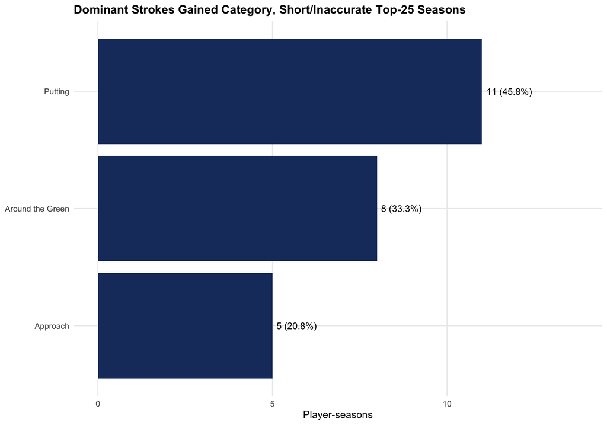

```r
p_dominant <- ggplot(dominant_tally, aes(x = reorder(dominant_label, n), y = n)) +
  geom_col(fill = COL_PRIMARY) +
  geom_text(aes(label = paste0(n, " (", pct, "%)")), hjust = -0.1) +
  coord_flip(ylim = c(0, max(dominant_tally$n) * 1.25)) +
  labs(
    title = "Dominant Strokes Gained Category, Short/Inaccurate Top-25 Seasons",
    x = NULL, y = "Player-seasons"
  ) +
  THEME_BASE

p_dominant
```

```r
top_dominant <- dominant_tally$dominant_label[1]
top_dominant_pct <- dominant_tally$pct[1]
n_categories_represented <- nrow(dominant_tally)
```

# Part 2: Short/Accurate — Does Accuracy Actually Compensate?

## 2.1 Are They Running a Real SG: Off-the-Tee Deficit?

```r
sa_all <- df_2007 %>% filter(archetype == "Short / Accurate")
sa_top25 <- top25_all %>% filter(archetype == "Short / Accurate")

pct_neg_ott_all   <- mean(sa_all$sg_ott < 0, na.rm = TRUE) * 100
pct_neg_ott_top25 <- mean(sa_top25$sg_ott < 0, na.rm = TRUE) * 100

cat("Short/Accurate, ALL player-seasons (2007-2025):\n")
```

```
## Short/Accurate, ALL player-seasons (2007-2025):
```

```r
cat("  n =", nrow(sa_all), " | % with negative SG:OTT =", round(pct_neg_ott_all, 1), "\n\n")
```

```
##   n = 1289  | % with negative SG:OTT = 51.2
```

```r
cat("Short/Accurate, Top-25 SG_total seasons:\n")
```

```
## Short/Accurate, Top-25 SG_total seasons:
```

```r
cat("  n =", nrow(sa_top25), " | % with negative SG:OTT =", round(pct_neg_ott_top25, 1), "\n")
```

```
##   n = 114  | % with negative SG:OTT = 22.8
```

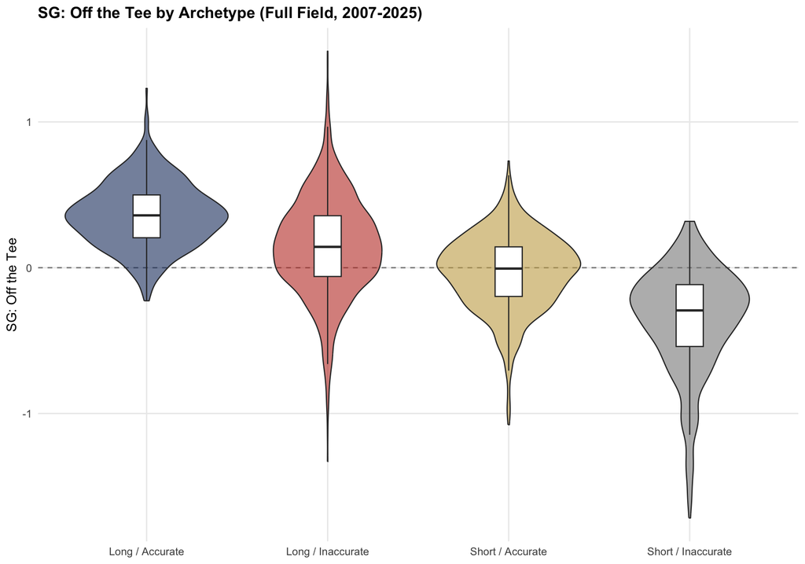

```r
p_ott_archetype <- ggplot(df_2007, aes(archetype, sg_ott, fill = archetype)) +
  geom_hline(yintercept = 0, linetype = "dashed", color = "grey50") +
  geom_violin(alpha = 0.6) +
  geom_boxplot(width = 0.15, outlier.shape = NA, fill = "white") +
  scale_fill_manual(values = archetype_colors) +
  labs(title = "SG: Off the Tee by Archetype (Full Field, 2007-2025)", x = NULL, y = "SG: Off the Tee") +
  THEME_BASE +
  theme(legend.position = "none")

p_ott_archetype
```

**Finding:** among *all* Short/Accurate player-seasons, 51.2% run a negative SG:OTT — being short usually does cost real strokes off the tee even when accuracy is above average. But among the subset good enough to reach the Top 25, that fraction drops to 22.8%: the ones who actually compete at the top overwhelmingly avoid a real off-the-tee deficit. Accuracy alone isn’t what separates a merely-average Short/Accurate season from an elite one — staying roughly neutral or positive off the tee, not just accurate, is what elite Short/Accurate players have in common.

## 2.2 How Much Accuracy Offsets How Many Yards Short?

A pooled interaction model, reusing the exact `lmer` structure from `03_distance_premium.Rmd` Section 7 (random intercept per player, age and year controls) but with `acc_vs_field` in the interaction term instead of `year`. This asks whether the “cost” of being short depends on how accurate a player is — and if so, by how much.

```r
df_model <- df_2007 %>% mutate(year_c = year - median(year))

fit_tradeoff <- lmer(
  sg_total ~ dist_vs_field * acc_vs_field + year_c + age + (1 | player_name),
  data = df_model
)

tidy(fit_tradeoff, effects = "fixed") %>% print()
```

```
## # A tibble: 6 x 5
##   effect term                        estimate std.error statistic
##   <chr>  <chr>                          <dbl>     <dbl>     <dbl>
## 1 fixed  (Intercept)                 0.237     0.0844       2.80
## 2 fixed  dist_vs_field               0.0422    0.00191     22.1
## 3 fixed  acc_vs_field                0.0726    0.00265     27.4
## 4 fixed  year_c                     -0.00508   0.00233     -2.18
## 5 fixed  age                        -0.00796   0.00245     -3.25
## 6 fixed  dist_vs_field:acc_vs_field  0.000166  0.000217     0.764
```

```r
coefs <- tidy(fit_tradeoff, effects = "fixed")
b0        <- coefs$estimate[coefs$term == "(Intercept)"]
b_dist    <- coefs$estimate[coefs$term == "dist_vs_field"]
b_acc     <- coefs$estimate[coefs$term == "acc_vs_field"]
b_da      <- coefs$estimate[coefs$term == "dist_vs_field:acc_vs_field"]
b_age     <- coefs$estimate[coefs$term == "age"]
int_t     <- coefs$statistic[coefs$term == "dist_vs_field:acc_vs_field"]
mean_age  <- mean(df_model$age, na.rm = TRUE)

b0_adj <- b0 + b_age * mean_age  # baseline at typical age, median year
```

**Finding:** the `dist_vs_field:acc_vs_field` interaction is 1.7^{-4} (t = 0.76) — not statistically distinguishable from zero. There is no strong evidence here that the trade-off rate between distance and accuracy itself changes across the range studied — distance’s cost and accuracy’s benefit are close to additive. The main effects are unambiguous either way: `dist_vs_field` (0.0422 SG per yard) and `acc_vs_field` (0.0726 SG per accuracy point) are both large relative to their standard errors — both matter for `sg_total`, independent of whether they interact.

### Breakeven curve

Solving the fitted model for the distance-vs-field value at which predicted `sg_total = 0`, as a function of `acc_vs_field` (holding age at its sample mean and year at the sample median):

$$\text{dist}^*(\text{acc}) =
\frac{-(b_0' + b_{\text{acc}} \cdot \text{acc})}{b_{\text{dist}} +
b_{\text{da}} \cdot \text{acc}}$$

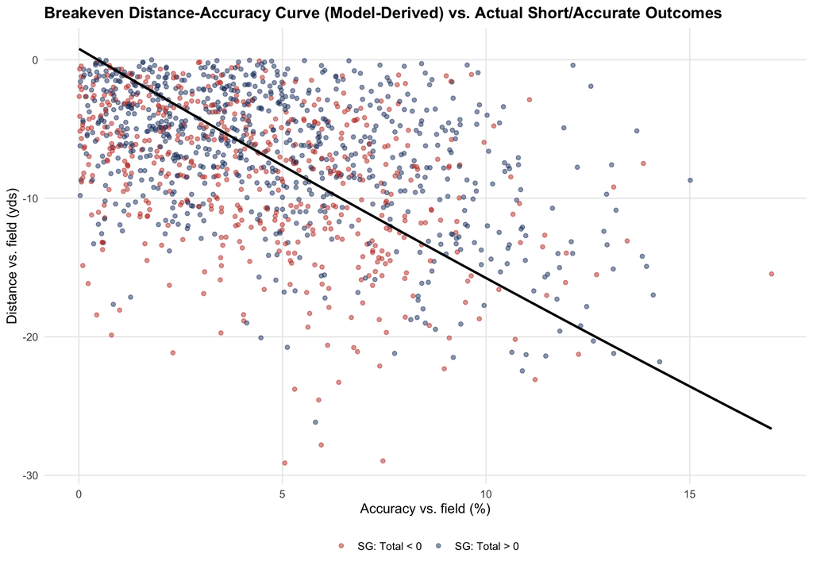

```r
acc_range <- range(df_2007$acc_vs_field[df_2007$archetype %in% c("Short / Accurate", "Long / Accurate")], na.rm = TRUE)
acc_seq <- seq(acc_range[1], acc_range[2], length.out = 200)

breakeven <- tibble(acc_vs_field = acc_seq) %>%
  mutate(dist_breakeven = -(b0_adj + b_acc * acc_vs_field) / (b_dist + b_da * acc_vs_field))

p_breakeven <- ggplot() +
  geom_point(data = df_2007 %>% filter(archetype == "Short / Accurate"),
             aes(acc_vs_field, dist_vs_field, color = sg_total > 0), alpha = 0.5, size = 1.5) +
  geom_line(data = breakeven, aes(acc_vs_field, dist_breakeven), color = "black", linewidth = 1) +
  scale_color_manual(values = c("TRUE" = COL_PRIMARY, "FALSE" = COL_ACCENT),
                      labels = c("TRUE" = "SG: Total > 0", "FALSE" = "SG: Total < 0"), name = NULL) +
  labs(
    title = "Breakeven Distance-Accuracy Curve (Model-Derived) vs. Actual Short/Accurate Outcomes",
    x = "Accuracy vs. field (%)", y = "Distance vs. field (yds)"
  ) +
  THEME_BASE

p_breakeven
```

**Finding:** the black line traces the model’s predicted breakeven point — the distance deficit a player can carry at a given accuracy level while still expecting `sg_total = 0`. Points above the line are the model’s predicted “should be positive” region; color shows what actually happened. Given the interaction term above is not statistically significant, this curve is expected to look **close to a straight line** over the range studied, not sharply bent — and that’s what a visual check of the plot should confirm. In other words: **there’s no evidence of a hard relative-distance threshold beyond which accuracy stops helping**; accuracy appears to buy back strokes lost to distance at a roughly constant rate across the range of Short/Accurate players actually observed. That’s a real answer to the user’s threshold question, just not the one a bend in the curve would have implied — the honest finding here is the *absence* of a threshold, not its location.

```r
# Where does the model's prediction diverge from what actually happened?
sa_check <- df_2007 %>%
  filter(archetype == "Short / Accurate") %>%
  mutate(
    predicted_breakeven = -(b0_adj + b_acc * acc_vs_field) / (b_dist + b_da * acc_vs_field),
    model_says_positive = dist_vs_field > predicted_breakeven,
    actual_positive = sg_total > 0
  )

agreement_rate <- mean(sa_check$model_says_positive == sa_check$actual_positive, na.rm = TRUE) * 100
cat("Model/actual agreement rate on sign of SG:Total, Short/Accurate players:", round(agreement_rate, 1), "%\n")
```

```
## Model/actual agreement rate on sign of SG:Total, Short/Accurate players: 56.6 %
```

**Finding:** the model-derived breakeven line agrees with the actual sign of `sg_total` for 56.6% of Short/Accurate player-seasons — a modest match, meaning the two-variable interaction model captures only part of what separates positive from negative seasons in this archetype — treat the curve as directional, not precise.

# Part 3: Summary